# R_Morgan_Project4_Presentation slides

## Project 4: Telecom Churn Prediction Modelling

### **Rhys Morgan, DAT9**

**20 Oct 2018**

**Background:** For subscription-based telecom providers, retaining customers is a significant priority. Retained customers become more loyal to your service, and provide opportunities for up-selling and cross-promotion.

A Telecoms company with a client base in America has collected data on a selection of its clients (anonymised), focused on customers phone activity and whether they chose to leave their account. They wish to know whether a customer is likely to leave their subscription service, i.e. whether a given customer will churn or not.

**Problem Statement:** Predict Customer churn, and determine the factors that lead customers to churn, in order to optimise the customer management process, giving us insights into customer retention, increasing lifetime value per customer, and identifying customers with further potential to market to.

**Project Goal:** Predict whether a customer will churn from the Telecom company's services.

**Null Hypothesis:** Customer churn is unaffected by independent variables, which present as random chance. Therefore, the probability of a customer churning is 50%.

**H0:** P = 0.5, +/- 0.05

**Alternate Hypothesis:** A customer’s chance of churning is affected by an independent variable, resulting in a higher or lower-than-equal probability of a customer churning ('True').

**H1:** P =\= 0.5 +/- 0.05

**Limitations:** Other factors aside from the phone use data may have contributed to the decision to churn, such as other plan features (e.g. internet use and cost within customers' plans) or reliability metrics (number of service outages etc). Also, we have no data on the nature of the customer service calls, and whether these resulted in a positive or negative experience.

### Data - Features and Target

20 features describing customer activities and attributes

1. **state** (Categorical, 51 unique values)
2. **account_length** (integer)
3. **area_code** (categorical, 3 unique values)
4. **phone_number** (categorical, 5000 unique values)
5. **international_plan** (categorical, 'Yes' or 'No')
6. **voice_mail_plan** (categorical, 'Yes' or 'No')
7. **num_of_voice_mail_messages** (integer)
8. **total_day_minutes** (integer)
9. **total_day_calls** (integer)
10. **total_day_charge** (float)
11. **total_eve_minutes** (integer)
12. **total_eve_calls** (integer)
13. **total_eve_charge** (float)
14. **total_night_minutes** (integer)
15. **total_night_calls** (integer)
16. **total_night_charge** (float)
17. **total_international_minutes** (integer)
18. **total_intl_calls** (integer)
19. **total_intl_charge** (float)
20. **number_customer_service_calls** (integer)
1. **churn** (Binary Target Column, 'True' or 'False')

### **Problem Breakdown:**

In tackling the problem statement of predicting churn, we wish to address the following :

> A. Classification Problem: Create an accurate machine learning model for predicting churn likelihood (churn or no churn) for a given customer, provided the data for that customer is available.

> B. Determine the most important data features that influence customer churn rate, and therefore optimise our model(s).

### Methodology

1. Explored the telecom customer dataset
2. Cleaned and prepared the data
3. Fit a classification ML model with our dataset to eliminate null hypothesis
4. Utilise various classification models for determining feature importance
5. Refit model after removing highlighted features (if any) and measure performance
6. Test other classification models for improvements

### Success Metrics:

1. **Accuracy Score**
2. **Area Under Curve (AUC)**

While both are useful metrics, I place more weight on a model's AUC, as it tests the discrimination ability of the model rather than its calibration, which the accuracy score does. While optimising a model requires calibration (to ensure predicted outcomes match actual outcomes), if it has no ability to discriminate beyond the proportion of recorded outcomes in the data, it isn't of much use.

### Additional notes:

**odds ratios** are calculated for coefficientes of linear models. They allow us to determine the association between a feature and likelihood of churning.

### Pre-step: Data analysis and preparation

Key Actions:

1. Our 3 'Total_X_minutes' features showed strong positive correlation with 'total_XXX_charge' features. Therefore, I removed the 'minutes' features to eliminate correlating features.
1. Once we converted categorical features to numerical features (through dummy variables and ordinal replacement values), scaled features using **StandardScaler**.
1. Our target feature ('churn') was heavily imbalanced. We therefore have to re-sample our data so that both '1' and '0' classes are equally represented in the data. We can accomplish this through **SMOTE-Tomek**.

### Cleaned Telecom Churn Data

```python
import pandas as pd

data = r"https://raw.githubusercontent.com/RhysZH/GA-DAT9-Projects1/master/R_Morgan_Project4_Files/telecom_data.csv"

df = pd.read_csv(data)
df.dtypes
```

```
account_length                     int64
num_of_voice_mail_messages         int64
total_day_calls                    int64
total_day_charge                 float64
total_eve_calls                    int64
total_eve_charge                 float64
total_night_calls                  int64
total_night_charge               float64
total_intl_calls                   int64
total_intl_charge                float64
number_customer_service_calls      int64
international_plan_n               int64
voice_mail_plan_n                  int64
area_code_408                      int64
area_code_415                      int64
area_code_510                      int64
churn_n                            int64
dtype: object
```

### Feature-Target Correlations

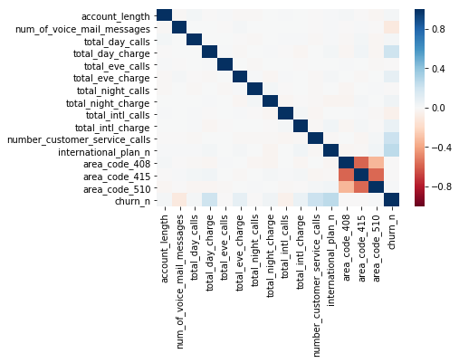

```python
dg = X.join(y)

sns.heatmap(dg.corr(),vmin=-1,vmax=1,center=0,cmap='RdBu')
```

#### Use Smote-Tomek to resample data

```python
#import counter to check shapes of original and resampled datasets
from collections import Counter
from imblearn.combine import SMOTETomek

smt = SMOTETomek(random_state=123)
X_res, y_res = smt.fit_sample(Xs, y)

X_samp = pd.DataFrame(X_res, columns = feature_names)

#Compare distributions of old and new datasets.
print('Original dataset shape {}'.format(Counter(y)))
print('Resampled dataset shape {}'.format(Counter(y_res)))
```

```
Original dataset shape Counter({0: 4293, 1: 707})
Resampled dataset shape Counter({0: 4292, 1: 4292})
```

## Model Selection

**Classification Models**

1. Logistic Regression Model (Logit)
2. K-Nearest Neighbours
3. Decision Trees

**Classification Models with Feature Selection capabilities**

1. SGDClassifier (ElasticNet Regularisation),
2. Random Forest Model

For feature selection models, I can refit the logistic regression model based on model results, removing highlighted features to see if success metrics are improved.

After re-sampling, the number of rows in the data has increased.

This is because SMOTE-Tomek heavily favoured SMOTE, which creates new estimated data points to bring the number of churned customers (y='1') up to the number of unchurned customers (y=0).

### 1. Logistic Regression Modelling

This model will give us a baseline AUC and accuracy score to base further investigation on. Our initial model will use a **80/20 Train/Test split** on the resampled, scaled dataset.

```python
from sklearn.linear_model import LogisticRegression
from sklearn.model_selection import train_test_split


# create training and testing vars, check shape
X_train, X_test, y_train, y_test = train_test_split(X_res, y_res, test_size=0.2,random_state=123)
print (X_train.shape, y_train.shape)
print (X_test.shape, y_test.shape)
```

```
(6867, 15) (6867,)
(1717, 15) (1717,)
```

```python
# Make an instance of a Logistic Regression object.
lr = LogisticRegression()
type(lr)

#fit model, print coefficients
model = lr.fit(X_train, y_train)
print('---Intercept---')
print(model.intercept_)
print('---Coefficients---')
print(model.coef_)
print('---Odds Ratios---')
print(np.exp(model.coef_))
```

```
---Intercept---
[-0.68334051]
---Coefficients---
[[ 0.06034927 -0.46044573  0.04311776  0.77387899 -0.01223031  0.43202967
  -0.06308781  0.25381826 -0.1568363   0.23789095  0.87602113  0.71344466
   0.02847505 -0.03032511  0.00648021]]
---Odds Ratios---
[[1.06220748 0.63100233 1.04406083 2.16816023 0.98784418 1.54038081
  0.93886103 1.28893753 0.85484399 1.26857085 2.4013261  2.04100976
  1.02888434 0.97013008 1.00650125]]
```

### Using Logit model for prediction

```python
#assign array with predicted 'y' results to 'y_predicted'
y_pred = model.predict(X_test)
y_pred
```

```
array([0, 1, 1, ..., 1, 0, 1])
```

```python
from sklearn import metrics

# calculate the fpr and tpr for all thresholds of the classification
probs = model.predict_proba(X_test)
preds = probs[:,1]
fpr, tpr, threshold = metrics.roc_curve(y_test, preds)
roc_auc = metrics.auc(fpr, tpr)
roc_auc
```

```
0.8555217146998706
```

### 1-b. K-fold cross validation on original Logit model

Using the logit model, I cross-validated its accuracy score, iterating through a loop that assigned the number of folds used for cross-validation. It then returned the best score, along with its corresponding value for K, which was 13.

This was the number of folds I used in cross validation, which justifies the number of folds I used as non-arbitrary.

```
no_folds    13.000000
scores       0.785193
Name: 11, dtype: float64
```

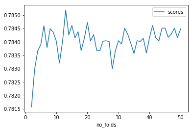

```python
#print no_folds with highest score
s = {'no_folds':no_folds, 'scores':score_list}
n_scores = pd.DataFrame(s)
print(n_scores.iloc[n_scores['scores'].values.argmax()])

#show cross-val scores against number of folds, visualising optimum k-value.
n_scores.plot('no_folds', 'scores')
```

#### Optimal number of folds is 13.

This was recorded for use for final cross-validation of all models.

```python
from sklearn.model_selection import cross_val_score

cv_lr = cross_val_score(model, X_res, y_res, cv=13, scoring='roc_auc').mean()
print('Cross-validated AUC for 1st Logit model is', cv_lr)
```

```
Cross-validated AUC for 1st Logit model is 0.8417751027870172
```

```python
y_pred_train = model.predict(X_train)
print('Logistic Regression Testing Accuracy:', metrics.accuracy_score(y_test, y_pred))
print('Logistic Regression Accuracy:',metrics.accuracy_score(y_train, y_pred_train))
print('---Confusion Matrix---')
print(metrics.confusion_matrix(y_true=y_test, y_pred=preds > .5))
```

```
Logistic Regression Testing Accuracy: 0.7815958066394875
Logistic Regression Accuracy: 0.7849133537206932
---Confusion Matrix---
[[660 183]
 [192 682]]
```

#### Initial Observations from Logit model

Looking at our testing accuracy, it is around 78% accurate, which is a good starting point. It has eclipsed our null accuracy of 50% (from resampling our data with Smote-Tomek), which rejects our null hypothesis.

Our testing and training scores are close, indicating model does not present with overfitting.

### 2. Elastic Net Regularisation

Use an ElasticNet model to identify features that do not impact the classification model significantly.

As this is a classification problem, we will use **SGDClassifier**

We require an optimal list of deprecated features, which neccessitates tuning our regularisation model. To tune, we have to determine the optimal value of the alpha hyper-parameter (which will heavily impact the Lambda hyper-parameter).

To get an optimal alpha, I iterated through a list of alphas, fitting a new model for each and returning only the alpha & coefficients with the highest AUC.

We then use this alpha to fit a new SGDClassifier model to get our final coefficients, which tell us which features we can remove for further modelling.

```python
from sklearn.linear_model import SGDClassifier


#define a range of alphas for optimising enet
alpha_range = 10.**np.arange(-2, 3)

opt_auc = 0
```

```python
#find optimal auc through optimal alpha, use coefficients for feature selection
for n in alpha_range:
    clf = SGDClassifier(penalty='elasticnet',alpha=n,max_iter=1000, loss = 'log',random_state=123)
    clf_model = clf.fit(X_train, y_train)
    predicted_enet = clf.predict_proba(X_test)
    preds = predicted_enet[:,1]
    fpr_enet, tpr_enet, threshold_enet = metrics.roc_curve(y_test, preds)
    roc_auc_enet = metrics.auc(fpr_enet, tpr_enet)

    #determine the optimum alpha by storing 'n' and its
    #associated metrics if AUC is larger than AUC for previous n.
    if roc_auc_enet >= opt_auc:
        opt_preds = preds
        opt_auc = roc_auc_enet
        opt_int = clf.intercept_
        opt_coef = clf.coef_
        opt_alpha = n
print('AUC for optimal alpha: ', opt_auc)
print('Optimal alpha: ', opt_alpha)
print('Intercept: ', opt_int)
print('coefficients: ',opt_coef)
```

```
AUC for optimal alpha:  0.8556031499140859
Optimal alpha:  0.01
Intercept:  [-0.61357972]
coefficients:  [[ 0.04362697 -0.40886348  0.03083594  0.69823179  0.          0.38294732
  -0.0473364   0.22019008 -0.13755107  0.20488582  0.78566804  0.65239969
   0.01523696 -0.02900043  0.        ]]
```

### Elastic net feature removal

elastic net regularisation deprecated the following features:

**1. 'total_eve_calls'**

**2. 'area_code_510'**

We will note these features, and re-fit our enet model with the optimal alpha, observing AUC.

```python
#Instantiate, fit and predict using a logistic elasticnet model.
clf_2 = SGDClassifier(penalty='elasticnet',alpha=0.01,max_iter=1000, loss = 'log',random_state=123)
clf_model_2 = clf_2.fit(X_train, y_train)
predicted_enet_2 = clf_2.predict_proba(X_test)
print('---Intercept---')
print(clf_model_2.intercept_)
print('---Coefficients---')
print(clf_model_2.coef_)
print('---Odds Ratios---')
print(np.exp(clf_model_2.coef_))
```

```
---Intercept---
[-0.61357972]
---Coefficients---
[[ 0.04362697 -0.40886348  0.03083594  0.69823179  0.          0.38294732
  -0.0473364   0.22019008 -0.13755107  0.20488582  0.78566804  0.65239969
   0.01523696 -0.02900043  0.        ]]
---Odds Ratios---
[[1.04459262 0.66440493 1.03131629 2.01019512 1.         1.46660077
  0.95376649 1.2463136  0.87148984 1.22738492 2.19387204 1.92014306
  1.01535363 0.97141604 1.        ]]
```

```python
preds = predicted_enet_2[:,1]
fpr_enet_2, tpr_enet_2, threshold_enet_2 = metrics.roc_curve(y_test, preds)
roc_auc_enet_2 = metrics.auc(fpr_enet_2, tpr_enet_2)
roc_auc_enet_2
```

```
0.8556031499140859
```

```python
cv_enet = cross_val_score(clf_model_2, X_res, y_res, cv=13, scoring='roc_auc').mean()
print('Cross-validated AUC for 2nd ElasticNet model is', cv_enet)
```

```
Cross-validated AUC for 2nd ElasticNet model is 0.8419853905420022
```

```python
y_pred = clf_model_2.predict(X_test)
y_pred_train = clf_model_2.predict(X_train)
print('ElasticNet Testing Accuracy:', metrics.accuracy_score(y_test, y_pred))
print('ElasticNet Training Accuracy:',metrics.accuracy_score(y_train, y_pred_train))
print('---Confusion Matrix---')
print(metrics.confusion_matrix(y_true=y_test, y_pred=preds > .5))
```

```
ElasticNet Testing Accuracy: 0.7839254513686663
ElasticNet Training Accuracy: 0.7856414737148683
---Confusion Matrix---
[[660 183]
 [188 686]]
```

With our optimised elasticnet model (with alpha = 0.01), we see a slight improvement in both testing accuracy and AUC. Improvement is only slight however. This is likely because our model was not initially overfitted.

Next, we shall consider the features that had their coefficients reduced to zero, and use them to re-fit our original Logit model.

### 3. Logit re-fit (removing features reduced from ENET)

From regularisation, I found that the features 'total_eve_calls' and 'area_code_510' did not meaningfully affect our model. Therefore, I removed these features and refit another logit model to see if it affects our success metrics. This 2nd logit model was fitted and evaluated according to the modelling workflow previously stated.

```python
lr = LogisticRegression()
model_2 = lr.fit(X_train, y_train)

print('---Intercept---')
print(model_2.intercept_)
print('---Coefficients---')
print(model_2.coef_)
print('---Odds Ratios---')
print(np.exp(model_2.coef_))
```

```
---Intercept---
[-0.68341447]
---Coefficients---
[[ 0.05991864 -0.46067446  0.04318374  0.77362579  0.43219535 -0.06329349
   0.25376489 -0.15693301  0.2380569   0.87616967  0.71362143  0.02216336
  -0.03794732]]
---Odds Ratios---
[[1.06175016 0.63085802 1.04412973 2.16761132 1.54063605 0.93866794
  1.28886874 0.85476131 1.26878138 2.40168283 2.04137056 1.02241079
  0.96276366]]
```

```python
cv_lr_2nd = cross_val_score(model_2, X_samp_f, y_res, cv=13, scoring='roc_auc').mean()
print('Cross-validated AUC for Refitted Logit model is', cv_lr_2nd)
```

```
Cross-validated AUC for Refitted Logit model is 0.8418858656171371
```

```python
y_pred = model_2.predict(X_test)
y_pred_train = model_2.predict(X_train)
print('2nd Logit Testing Accuracy:', metrics.accuracy_score(y_test, y_pred))
print('2nd Logit Training Accuracy:',metrics.accuracy_score(y_train, y_pred_train))
print('---Confusion Matrix---')
print(metrics.confusion_matrix(y_true=y_test, y_pred=preds > .5))
```

```
2nd Logit Testing Accuracy: 0.7833430401863716
2nd Logit Training Accuracy: 0.7846221057230232
---Confusion Matrix---
[[662 181]
 [191 683]]
```

There was slight improvement, the score was not affected significantly from the regularisation and refits - the overall testing accuracy is still around 78%.

Ideally, our prediction accuracy should be around 95% (though this isn't the only metric of value).

To achieve this, I fit the telecom data to non-linear models to evaluate their suitability.

### 4. K-Nearest Neighbour Classification

K-Nearest Neighbour (KNN) classifies data based on the classes of the datapoints that are closest to it (in other words, their neighbours.

I modelling the telecom data based on my previous workflow, creating a set of predicted classes from test dataset to compare against the actual values from that same test data.

### Deriving optimum number of neighbours

```
knn_acc           0.950495
num_neighbours    2.000000
Name: 0, dtype: float64
```

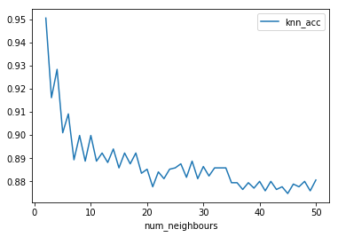

```python
knn_acc = []
num_neighbours = []

for n in range(2,51):
    knn = KNeighborsClassifier(n_neighbors=n)
    knn_model = knn.fit(X_train, y_train)
    predicted_knn = knn_model.predict(X_test)
    knn_acc.append(accuracy_score(y_test, predicted_knn))
    num_neighbours.append(n)

#create DataFrame of scores and num_neighbours, plot.
s = {'knn_acc':knn_acc, 'num_neighbours':num_neighbours}
knn_scores = pd.DataFrame(s)
print(knn_scores.iloc[knn_scores['knn_acc'].values.argmax()])
knn_scores.plot('num_neighbours', 'knn_acc')
```

```python
knn_13 = KNeighborsClassifier(n_neighbors=2)
knn_model = knn.fit(X_train, y_train)
predicted_knn = knn.predict_proba(X_test)
preds = predicted_knn[:,1]
fpr_knn, tpr_knn, threshold_knn = metrics.roc_curve(y_test, preds)
roc_auc_knn = metrics.auc(fpr_knn, tpr_knn)
roc_auc_knn
```

```
0.9429878851546319
```

```python
cv_knn = cross_val_score(knn_model, X_res, y_res, cv=13, scoring='roc_auc').mean()
print('Cross-validated AUC for KNN model is', cv_knn)
```

```
Cross-validated AUC for KNN model is 0.9304754192104038
```

```python
y_pred = knn_model.predict(X_test)
y_pred_train = knn_model.predict(X_train)
print('KNN Testing Accuracy:', metrics.accuracy_score(y_test, y_pred))
print('KNN Training Accuracy:',metrics.accuracy_score(y_train, y_pred_train))
print('---Confusion Matrix---')
print(metrics.confusion_matrix(y_true=y_test, y_pred=preds > .5))
```

```
KNN Testing Accuracy: 0.8806057076295865
KNN Training Accuracy: 0.8572884811416922
---Confusion Matrix---
[[708 135]
 [ 70 804]]
```

The confusion matrix shows a larger number of true positives and true negatives, which are reflected in a high AUC and improved accuracy.

### 5. Decision Tree Model

The decision tree model attempts to classify customers (datapoints) by creating a logic for classification based on the most important attributes of each customer.

```python
cv_dtree = cross_val_score(dtree_model, X_samp_f, y_res, cv=13, scoring='roc_auc').mean()
print('Cross-validated AUC for Decision Tree model is', cv_dtree)
```

```
Cross-validated AUC for Decision Tree model is 0.9198652807414137
```

```python
y_pred = dtree_model.predict(X_test)
y_pred_train = dtree_model.predict(X_train)
print('Decision Tree Testing Accuracy:', metrics.accuracy_score(y_test, y_pred))
print('Decision Tree Training Accuracy:',metrics.accuracy_score(y_train, y_pred_train))
print('---Confusion Matrix---')
print(metrics.confusion_matrix(y_true=y_test, y_pred=preds > .5))
```

```
Decision Tree Testing Accuracy: 0.9376820034944671
Decision Tree Training Accuracy: 1.0
---Confusion Matrix---
[[792  51]
 [ 56 818]]
```

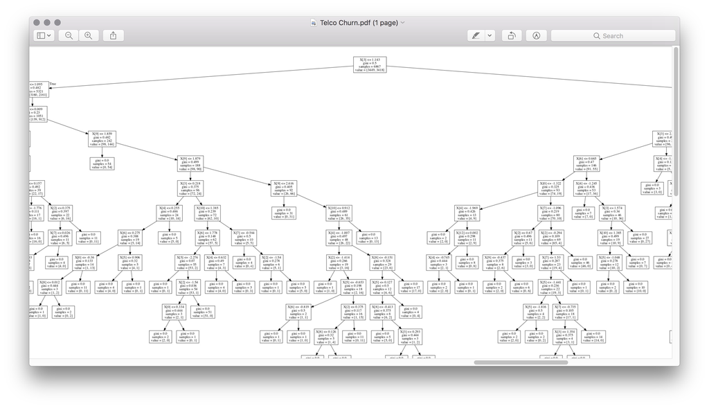

```python
from IPython.display import Image

Image(filename= r'/Users/meisan/Documents/GitHub/GA-DAT9-Projects1/R_Morgan_Project4_Files/DTreePhoto.jpg')
```

```python
#from observing chart, print features at the top of the decision tree.
print(enet_predictors[3],',',enet_predictors[7],',',enet_predictors[9],',',enet_predictors[10])
```

```
total_day_charge , total_intl_calls , number_customer_service_calls , international_plan_n
```

From the decision tree visualisation, the model decided that the **total_day_charge , total_intl_calls , number_customer_service_calls** and **international_plan_n** features were the most significant attributes.

### 6-a. Random Forest Model

The random forest model essentially generates a large number of decision trees, then classifies data based on the most common resulting class of all the trees.

However, another reason for using this model was for its attribute **feature importances_**, which let me rank features on their influence in determining churn.

```python
#split data according to original dataset
X_train, X_test, y_train, y_test = train_test_split(X_res, y_res, test_size=0.2,random_state=123)

from sklearn.ensemble import RandomForestClassifier

#Instantiate a Random Forest Classifier object
rf_clf = RandomForestClassifier(n_estimators=100)
```

```python
cv_rf = cross_val_score(rf_model, X_samp_f, y_res, cv=13, scoring='roc_auc').mean()
print('AUC for Random Forest model:', roc_auc_rf)
print('Cross-validated AUC for Random Forest model:', cv_rf)

#Our cross-validate AUC is very close to 1, meaning this model has very high discrimation ability.
```

```
AUC for Random Forest model: 0.9955712816002562
Cross-validated AUC for Random Forest model: 0.9945278449483455
```

```python
rf_y_pred = rf_clf.predict(X_test)
rf_pred_train = rf_clf.predict(X_train)
print('RandForest Testing Accuracy:', metrics.accuracy_score(y_test, rf_y_pred))
print('RandForest Training Accuracy:',metrics.accuracy_score(y_train, rf_pred_train))
print('---Confusion Matrix---')
print(metrics.confusion_matrix(y_true=y_test, y_pred=preds > .5))
```

```
RandForest Testing Accuracy: 0.966802562609202
RandForest Training Accuracy: 1.0
---Confusion Matrix---
[[825  18]
 [ 39 835]]
```

### 6-b. Feature Importance from Random Forest

By plotting the attribute 'feature_importance' from our RF Model, we can ascertain which features were influential in predicting churn for the largest number of customers.

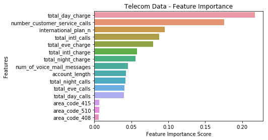

```python
# Create a bar plot for feature importance
sns.barplot(x=feature_imp, y=feature_imp.index)
# Add labels
plt.xlabel('Feature Importance Score')
plt.ylabel('Features')
plt.title("Telecom Data - Feature Importance")
plt.show()
```

From observation of feature importances, our most influential features are the same as those for our decision tree. Feature importance ranks each feature by the percentage of datapoints that a given feature influenced their classification. Note that this does not imply causation only that a relationship exists.

Our three 'area_code' features have little impact on our model, so we can remove them and re-fit a final logit model to see if AUC improves.

```python
rf_predictors = ['account_length','num_of_voice_mail_messages','total_day_calls',
                 'total_day_charge','total_eve_charge','total_night_calls',
                 'total_night_charge','total_intl_calls','total_intl_charge',
                 'number_customer_service_calls','international_plan_n']
#assign RandomForest predictors to balanced X data
X_samp_randf = X_samp[rf_predictors]

#split data
X_train, X_test, y_train, y_test = train_test_split(X_samp_randf, y_res, test_size=0.2,random_state=123)
```

```python
lr_3 = LogisticRegression()
model_3 = lr_3.fit(X_train, y_train)

print('---Intercept---')
print(model_3.intercept_)
print('---Coefficients---')
print(model_3.coef_)
print('---Odds Ratios---')
print(np.exp(model_3.coef_))
```

```
---Intercept---
[-0.68226722]
---Coefficients---
[[ 0.06175888 -0.45967446  0.04204446  0.77321414  0.43409925 -0.06535415
   0.2517267  -0.15573256  0.23431221  0.87546184  0.71438772]]
---Odds Ratios---
[[1.06370584 0.63148919 1.04294085 2.16671922 1.54357206 0.93673566
  1.28624446 0.85578803 1.26403908 2.39998345 2.04293546]]
```

```python
#cross-validate AUC
cv_lr_3rd = cross_val_score(model_3, X_samp_randf, y_res, cv=13, scoring='roc_auc').mean()
print('AUC for Final Logit model is', roc_auc_3)
print('Cross-validated AUC for Final Logit is', cv_lr_3rd)
```

```
AUC for Final Logit model is 0.8559261762638066
Cross-validated AUC for Final Logit is 0.8420713453878208
```

```python
y_pred = model_3.predict(X_test)
y_pred_train = model_3.predict(X_train)
print('Final Logit Testing Accuracy:', metrics.accuracy_score(y_test, y_pred))
print('Final Logit Training Accuracy:',metrics.accuracy_score(y_train, y_pred_train))
print('---Confusion Matrix---')
print(metrics.confusion_matrix(y_true=y_test, y_pred=preds > .5))

#Again, our scores improved only slightly, therefore supporting that Logistic regression is likely a sub-optimal fit for our business data and problem.
```

```
Final Logit Testing Accuracy: 0.7897495631916133
Final Logit Training Accuracy: 0.7830202417358381
---Confusion Matrix---
[[665 178]
 [183 691]]
```

### 9. Plot ROC and AUC for all models

I've opted to present all cross-validated AUC's and their associated ROC curves for all models at once, to faciliate direct comparison.

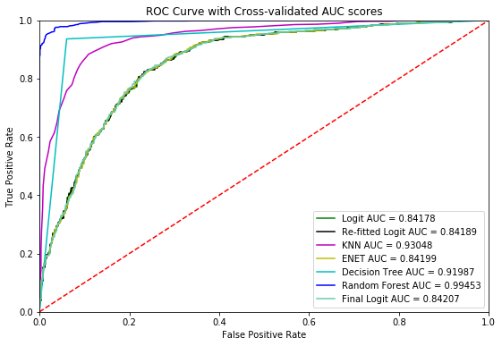

```python
#Plot CV AUC for all models
fig, ax = plt.subplots(figsize=(9, 6))
plt.title('ROC Curve with Cross-validated AUC scores')
plt.plot(fpr, tpr, 'g', label = 'Logit AUC = %0.5f' % cv_lr)
plt.plot(fpr_2, tpr_2, 'k', label = 'Re-fitted Logit AUC = %0.5f' % cv_lr_2nd)
plt.plot(fpr_knn, tpr_knn, 'm', label = 'KNN AUC = %0.5f' % cv_knn)
plt.plot(fpr_enet_2, tpr_enet_2, 'y', label = 'ENET AUC = %0.5f' % cv_enet)
plt.plot(fpr_tree, tpr_tree, 'c', label = 'Decision Tree AUC = %0.5f' % cv_dtree)
plt.plot(fpr_rf, tpr_rf, 'b', label = 'Random Forest AUC = %0.5f' % cv_rf)
plt.plot(fpr_3, tpr_3, '#66CDAA', label = 'Final Logit AUC = %0.5f' % cv_lr_3rd)
plt.legend(loc = 'lower right')
plt.plot([0, 1], [0, 1],'r--')
plt.xlim([0, 1])
plt.ylim([0, 1])
plt.ylabel('True Positive Rate')
plt.xlabel('False Positive Rate')
plt.show()
```

### Conclusions

From our 7 models (5 different types), the Random Forest model displayed both the highest accuracy and AUC. We can therefore use this model on to predict if new customers will churn, based on new customer data as it is collected.

While Logistic regression models displayed lower success metrics, the ability to see the coefficients for each metric allows us to see the association of each metric to the target via odds ratios.

### Next Steps

- The Random Forest model fitted in this report can now be used to predict churn with a high degree of accuracy
- Model can be deployed as a web app (using flask and pickle), accepting an array of feature values from user to predict churn.
- Feature importances act as points to investigate further for marketing activities, thereby potentially lowering the rate of churn.
- The logistic regression models may also be able to be improved over time, or by tuning hyperparameters to optimise accuracy.

### Further Considerations

- While this dataset was sufficient to predict churn to an acceptable accuracy (through random forest), changes in data over time may result in the model losing its effectiveness.
- This dataset focuses only on voicemail, minutes usage and charges. However, logically there are other features that may influence customers to leave their telecom subscription.